# 第1回 イントロダクション／情報検索と Excel の基本

## 関数の直接入力

1. すぐ下の **C17** を選ぶ  
   （A17 は「関数で平均」）
2. `=AVERAGE(` まで打つ
3. 2025年の列をドラッグ
4. `Enter` で確定  
   （`)` は省いてよい）

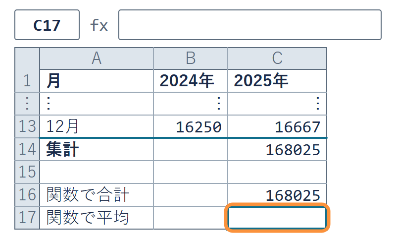

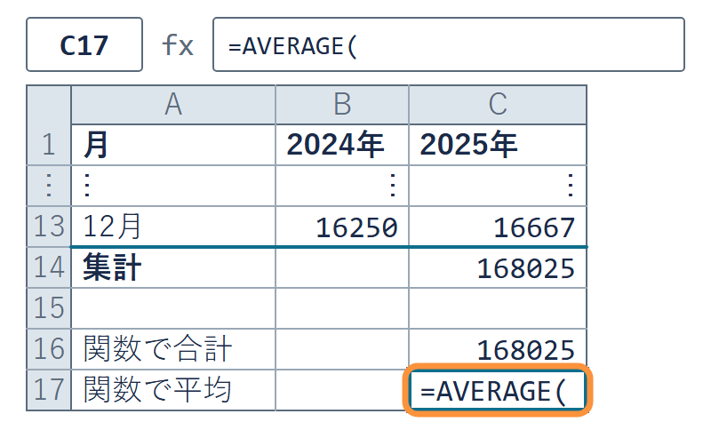

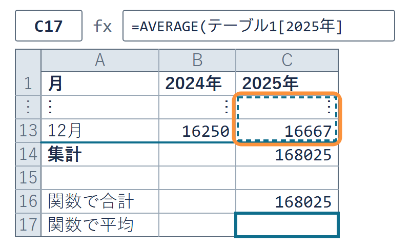

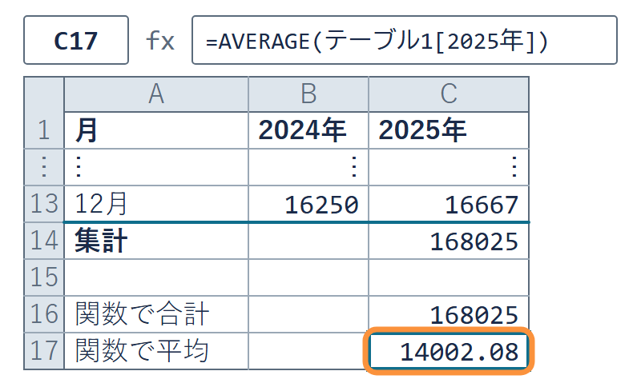

名前を覚えたら、こちらが速い。**どちらの道でも同じ答え**  
C17 は、小数第 2 位まで表示すると 14002.08

## 2 通りの答えを突き合わせる

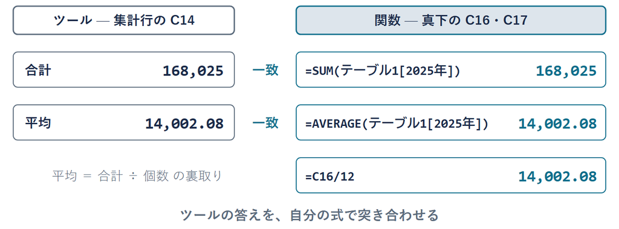

合計は集計行の C14 と真下の C16 が一致  
`=C16/12` も 14,002.08 で、平均 ＝ 合計 ÷ 個数 の裏も取れる

## 照合が見つける取りこぼし

番地で範囲を書き損じる  
`=SUM(C2:C12)`  
→ **151,358**  
12月（C13）が抜けた

列の名前で書く  
`=SUM(テーブル1[2025年])`  
→ **168,025**  
テーブルに 12 か月すべてあれば  
列の名前で全体を指せる

- **なぜ起きるか**：ドラッグが 1 行手前で止まっても、答えは出てしまう
- **どう見つけるか**：真上の集計行 C14 の 168,  
  025 と突き合わせると、16,667 足りない
- **どう防ぐか**：テーブルにして、列の名前で指す

照合は儀式ではない。ずれたら、そこに原因がある

## 差の列の入力

- **列を足す**：D1 に「差」と打つ。テーブルが D 列まで広がる
- **打つ**：D2 に `=C2-B2` と打って `Enter`。C2・B2 はキーで打つ
- **意味**：同じ行の 2025年 − 2024年。1月なら 658
- **先に予想**：D3 から下は、空のままか、埋まるか

`=13866-13208` と数字を埋めず、番地で指す。予想してから `Enter`

## 計算列

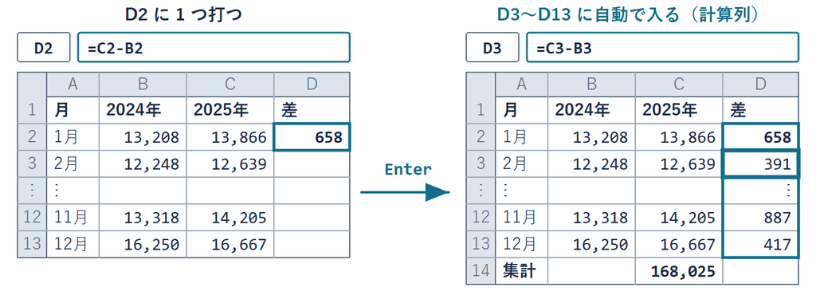

テーブルの列は、式を 1 つ打てば全部の行に入る（**計算列**）  
12 か月すべてが正。いちばん小さいのは 2月の +391 で、いちばん大きいのは 11月の +887

## 相対参照

定義

**相対参照**＝式をコピーすると、番地が同じだけずれて入る書き方

- **計算列の D3**：D3 は `=C3-B3`。テーブルが D2 の式をコピーした
- **なぜずれるか**：式が「自分の左となり 2 つ」  
  という**位置の関係**を覚えているため
- **テーブルでない範囲でも**：コピーすれば、同じだけずれる

式が覚えているのは住所ではなく「自分の左となり 2 つ」という関係

## オートフィルによる式のコピー

1. テーブルでない範囲の  
   D2 に `=C2-B2`
2. 右下の**フィルハンドル**を  
   **D13 まで**ドラッグ
3. 手を離す  
   D3 は `=C3-B3`

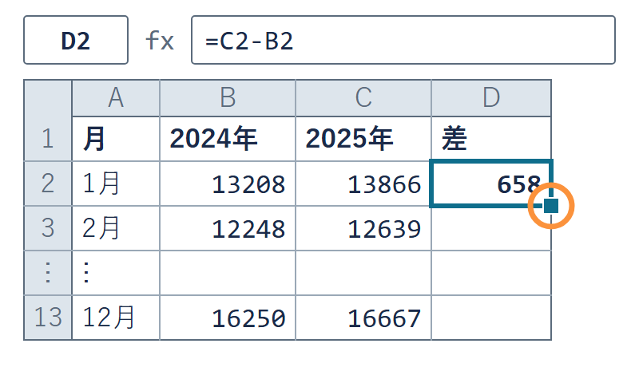

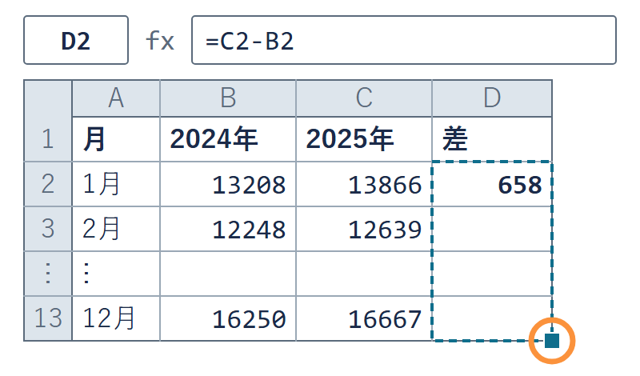

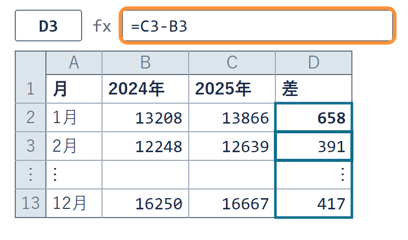

テーブルは `Enter` だけ（計算列）。テーブルでない範囲は自分で引く  
1 行下へ進むたびに、行番号も 1 つ下がる。D13 は `=C13-B13`

## ズレるのは機能

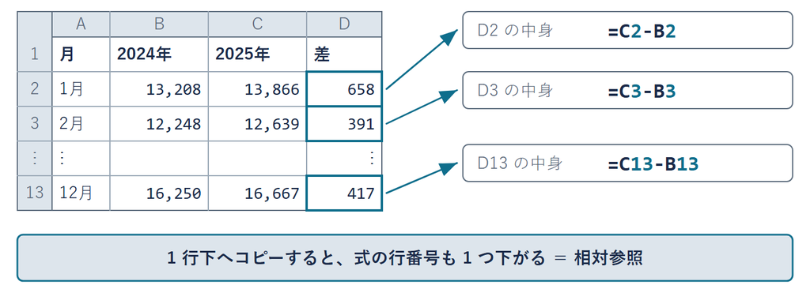

ズレなかったら、12 行とも 1月の差 658 が並んでしまう

## 式は生きている — 2025年 6 月を書き換える

1. **差も集計する**：D14 の ▼ で「合計」。差の合計 7,495
2. **予想する**：C7（2025年 6 月）を書き換えたら、どこが動くか
3. **書き換える**：C7 に好きな数を打って `Enter`
4. **観察する**：D7・C14・D14・C16・C17 が同時に動く
5. **戻す**：`Ctrl + Z`（Mac では `⌘ + Z`）

1 マス直せば、全部が追いかける — 電卓との差はここ

## 発展 構造化参照による差の列

1. **E1** に見出し  
   「差（発展）」
2. **E2** で `=`、**C2** をクリック  
   `-`、**B2** をクリック
3. `Enter` で  
   E3〜E13 も埋まる

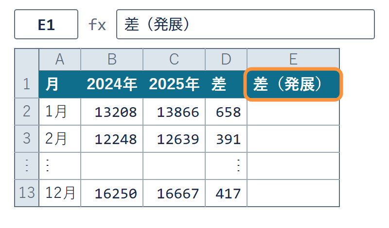

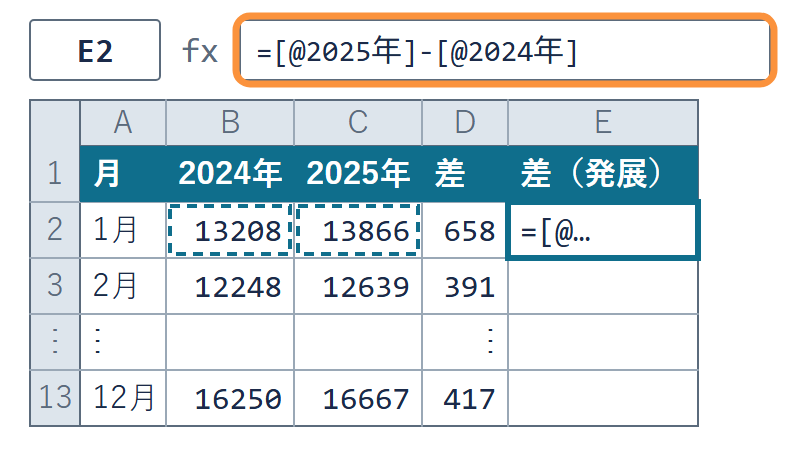

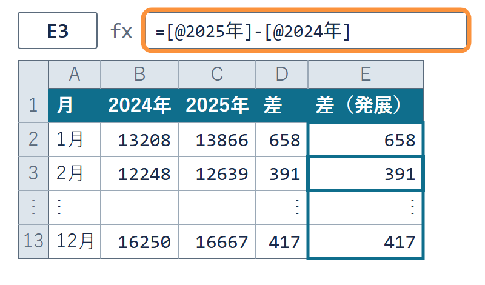

`[@2025年]` は「**同じ行の、2025年の列**」。E3 も同じ式で、行番号を書かない  
クリックで作るとこの形。答えは D 列と同じ

## 桁区切りの書式設定

1. 数の範囲 **B2:C13** を選ぶ
2. 「ホーム」タブの  
   カンマのボタン  
   （桁区切りスタイル）
3. B2 を選ぶと数式バーは  
   **13208** のまま

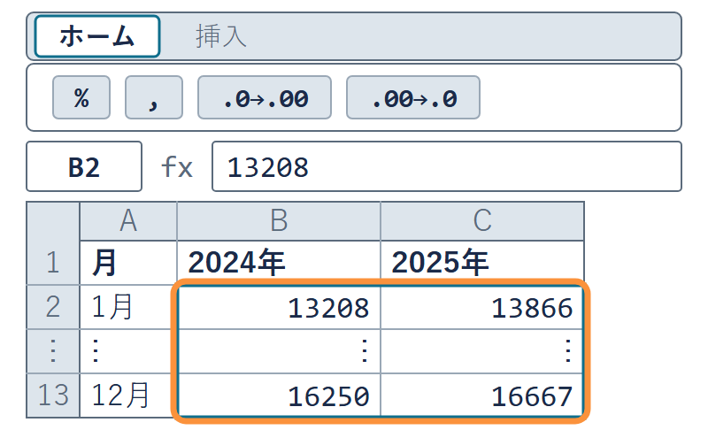

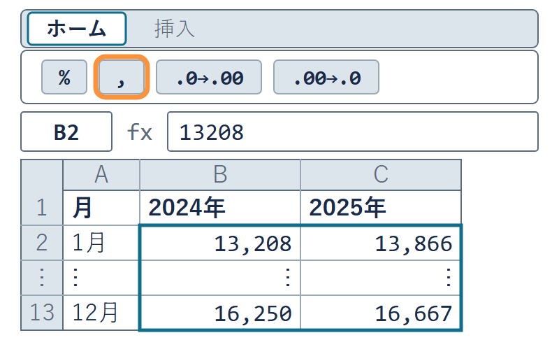

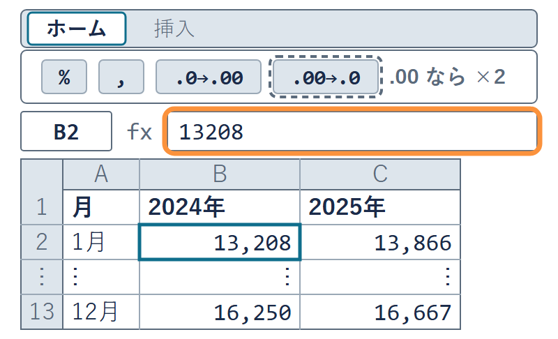

**書式は見た目だけ**。もし `.00` が付いたら、B2:C13 をもう一度選び  
［小数点以下の表示桁数を減らす］を 2 回押す

## Q&A

Q1 オートフィルで式を引いたら、罫線や色が消えた

「オートフィル オプション」→**「書式なしコピー (フィル)」**

Q2 C2・B2 をクリックしたのに、式が `[@2025年]` の形で出る

**これは正常**。「同じ行の、その列」と読む

Q3 C16 の合計が、集計行の 2 倍（336,050）になった

範囲に**集計行の C14 まで**入っている。C13 で止めるか、列の名前で指す

Q4 桁区切りを押したら、`.00` が付いた

B2:C13 を選び直し、［小数点以下の表示桁数を減らす］を 2 回押す

## 演習 1-3 — 2 通りで出して照合する

演習 1-3

合計と平均をツールと関数で出し、一致を確かめる

- 前のトピックで作った表に集計行を足し、C14 に 2025年の合計を出す
- 真下の C16・C17 に SUM と AVERAGE を書き、C14 と照合する
- 式の名前は**自分の表の名前**（「テーブルデザイン」タブの「テーブル名」欄）
- D1 に「差」、D2 に `=C2-B2`、E2 に発展の式。最後に桁区切り

✋ 動画を止めて 8 分。一致を確かめたら再生に戻る

数字は出た。次は、この数字を線にして言葉にする

経済データ入門

第1回 — Topic04

可視化・解釈・検証

グラフを読み、AI の答えを検収する

## この回の道のり

1

出所と出典

2

画面と構造

演習 1-2

24 個をテーブルに

3

集計と参照

演習 1-3

2 通りで照合

4

可視化と検証

演習 1-4

線と言葉と突き合わせ

いまここ — 出した数を線にして、言葉にして、突き合わせる

## 前のトピックで出した数

前トピックのポイント — 集計関数と相対参照

Q: いま手元の表には、何が入っているか

- **合計**：2025年は 168,025（集計行と SUM で一致）
- **平均**：2025年は 14,002.08（`=C16/12` でも同じ値）
- **差の列**：12 か月すべてが正で、集計は 7,495

この表を線にして、動きを言葉にする

## このトピックで身につけるもの

- **線にする**：折れ線を 2 つの道で描き、見た目を整える
- **言葉にする**：動きを数字つきの 1 行にし、出典を添える
- **準備する**：分析ツールを有効にする。  
  分析ツール＝統計の計算結果をまとめて表に出す追加機能
- **突き合わせる**：AI の答えを、自分のシートと一次ソースで照合

このトピックの到達点は、AI の答えを自分の手で確かめられること

## 線にして、言葉にして、突き合わせる

宣言

出した数を**線にし**、動きを**言葉にし**、**別の目で突き合わせる**

- **何をやるか**：折れ線グラフ → 1 行の言葉 → AI との突き合わせ
- **なぜやるか**：表の 24 個を眺めても、動きは読み取りにくい
- **いつ必須か**：レポートに図や AI の答えを載せるとき

読んで確かめた数字だけが、根拠になる

## 描く前に予想する — いちばん高い月は

- **問い**：2025年の 12 か月で、販売額がいちばん高いのは何月か
- **選ぶ**：3月（年度末）／8月（お盆）／12月（年末）の 3 つから 1 つ
- **書く**：演習シートの「予想」の欄に、選んだ月を書いておく

✋ 動画を止めて、予想を 1 つ書いてから再生に戻る

予想があると、線を見たときに「当たった／外れた」が残る

## 折れ線グラフの作成

1. 「テーブルデザイン」で  
   **集計行**の印を外す
2. 表の中のセルを  
   1 つ選ぶ
3. 「挿入」タブの  
   グラフから**折れ線**
4. 「データの選択」で  
   **差**の系列を削除

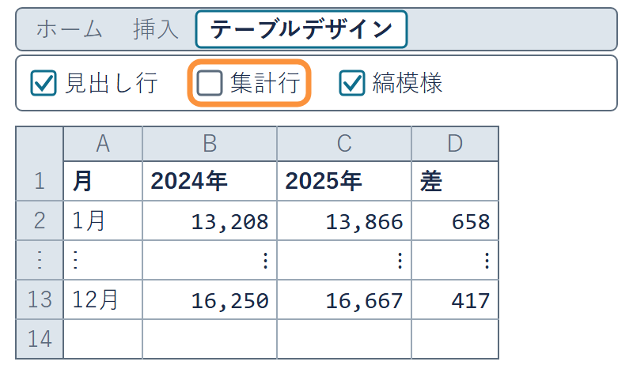

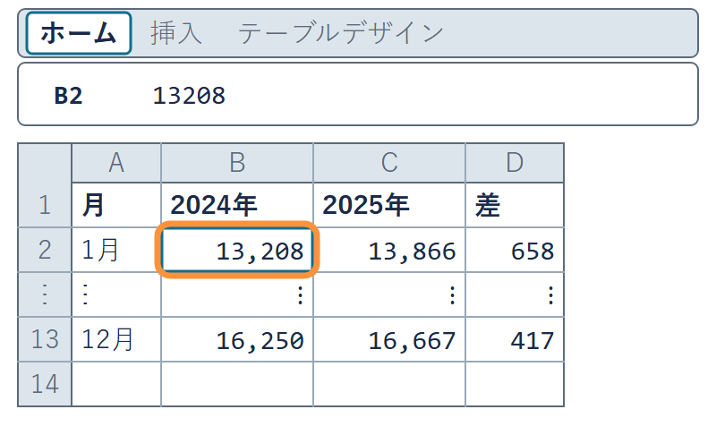

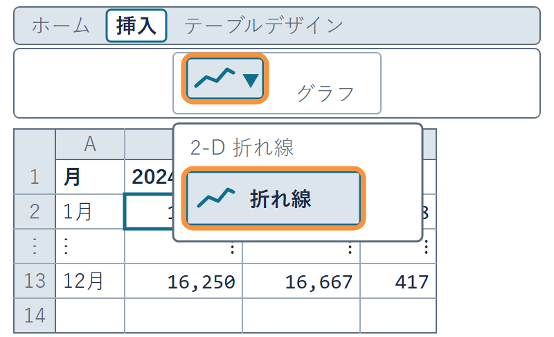

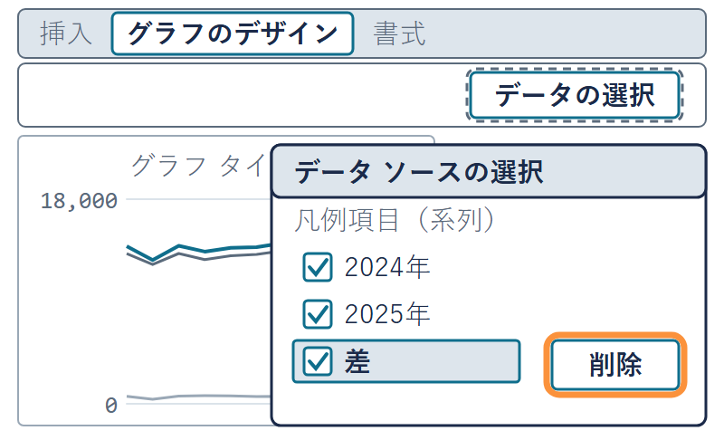

テーブルから描けば、行を足したときに線も伸びる

## 折れ線を選ぶ 2 つの道

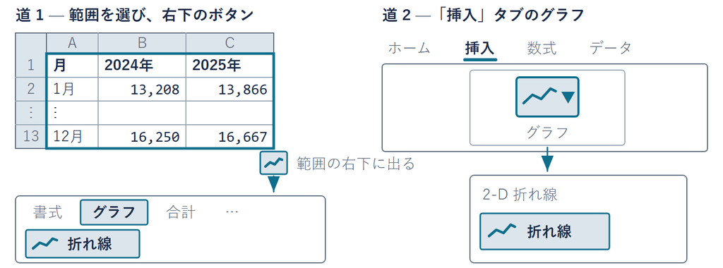

どちらの道でも、できる折れ線は同じ  
道 1（右下のボタン）は Windows 用。Mac は道 2 の「挿入」から描く

## 整える前と後

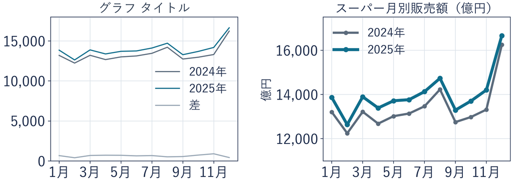

「差」は数百で桁が違うので外す（見るなら別のグラフか第 2 軸へ）  
タイトル・軸ラベル・凡例は「グラフ要素」（次のページ）  
表示範囲は「軸の書式設定」／線の色と太さは「データ系列の書式設定」

## グラフ要素の追加

1. グラフの中を  
   クリックして選ぶ
2. 右上の **＋**  
   （グラフ要素）を押す
3. **グラフ タイトル**・  
   **軸ラベル**・**凡例**に印
4. タイトルと軸ラベルの  
   文字を書き換える

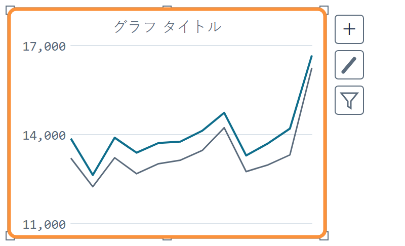

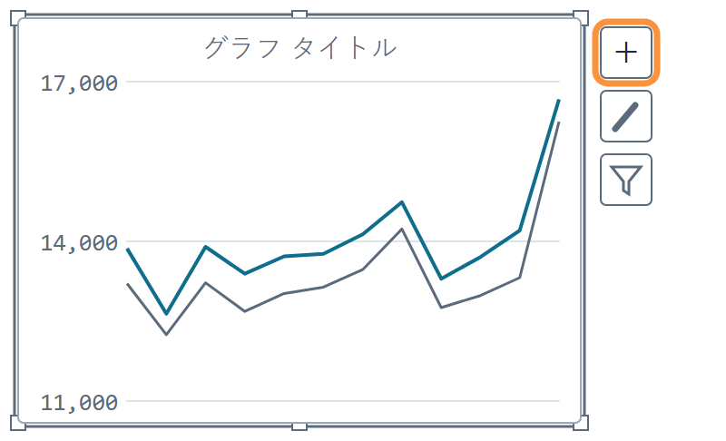

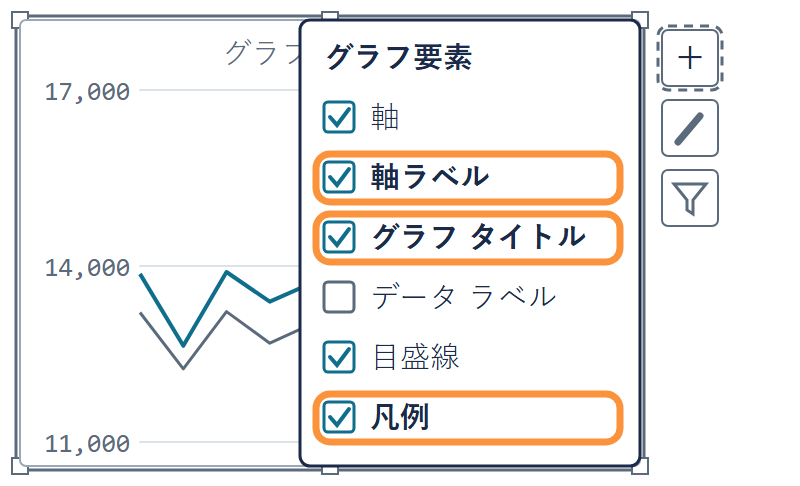

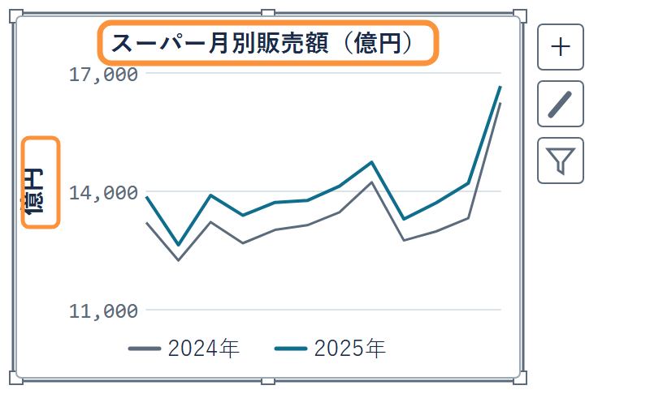

タイトルは「スーパー月別販売額（億円）」、縦軸は「億円」

## Mac のグラフ要素の追加

1. グラフの中を  
   クリックして選ぶ
2. 「グラフのデザイン」の  
   「グラフ要素を追加」
3. **グラフ タイトル**・  
   **軸ラベル**・**凡例**を選ぶ

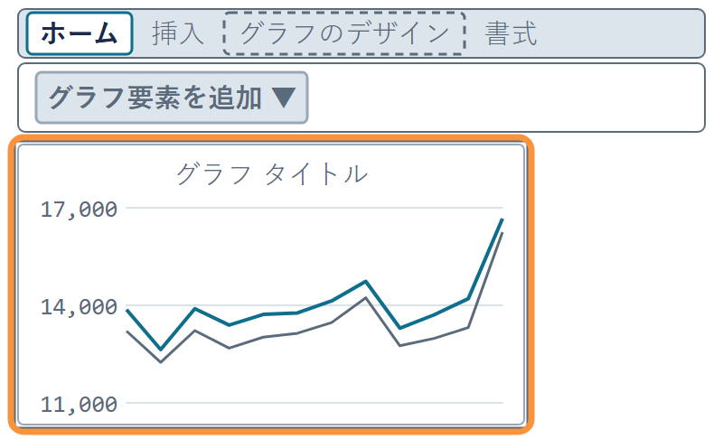

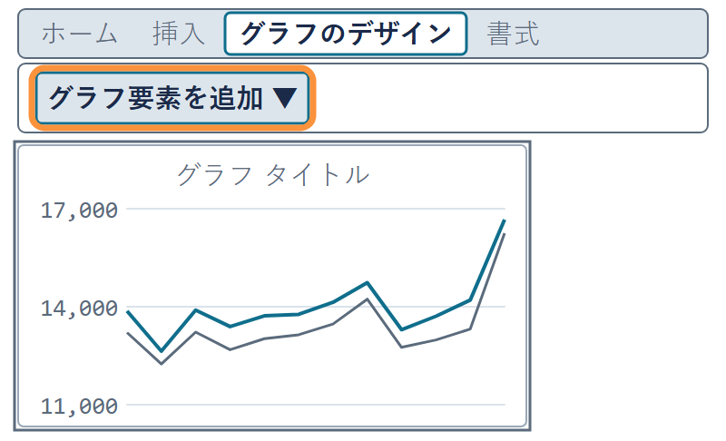

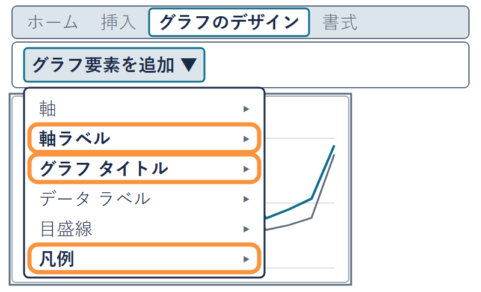

Mac のグラフには右上の **＋** が無い。入口はリボンのタブ

## 縦軸の目盛りの範囲

1. 縦軸の数字を  
   右クリック
2. 一覧の  
   「軸の書式設定」
3. 「最小値」に  
   **11000** と打つ

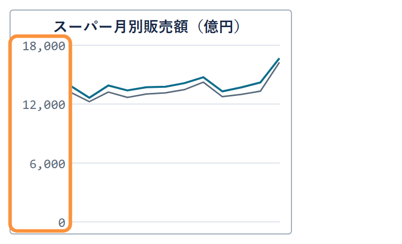

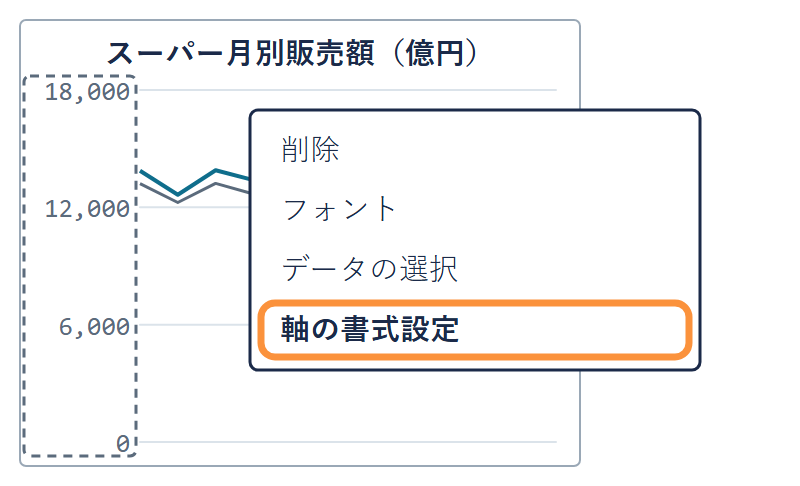

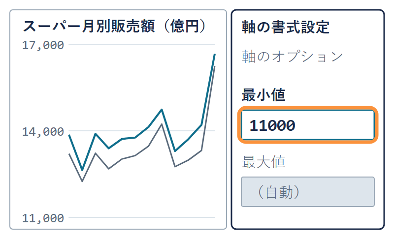

0 から始めると線が上に寄る  
最小値を上げると、月ごとの差が見える

## 線を読む — 山と谷

[figure not shown]

出典: 経済産業省「商業動態統計調査（2024年・2025年）」  
百貨店・スーパー商品別販売額、2026-09-22 取得

## 動きを 1 行の言葉にする

1 行

販売額は 12月に月平均の**約 1.19 倍**まで跳ね上がり  
2月に最も落ち込む。今年は **12 か月すべてで前年を上回った**

- **山**：12月が年間のピーク。16,667 は月平均 14,002 の約 1.19 倍
- **谷**：2月が最も低い。12,639 は約 0.90 倍で、日数の少なさも影響か
- **前年比**：差の列がすべて正（+391〜+887）。年間で +7,495 億円

グラフは作って終わりにしない。**数字つきの 1 行**で語る

## 言ってよいことの境界

言い切れない  
「消費が強くなった」  
物価の上昇分と店の数の増減を  
分けていない

言える  
12 か月すべてで  
名目の販売額が前年を上回った

- **名目値**：物価が上がった分も含む金額
- **全店か既存店か**：全店の販売額には、店舗数の増減の影響も含まれる
- **出典の 1 行**：図の下に、機関・統計名と年・表名・取得日の 4 点

データカードの落とし穴が、そのまま言ってよいことの境界

## 分析ツールの有効化

1. 「ファイル」→  
   「オプション」
2. 左の一覧の  
   「アドイン」
3. 管理を「Excel アドイン」  
   にして「設定」
4. 「分析ツール」に  
   印を付けて OK
5. 「データ」タブの右端に  
   「データ分析」

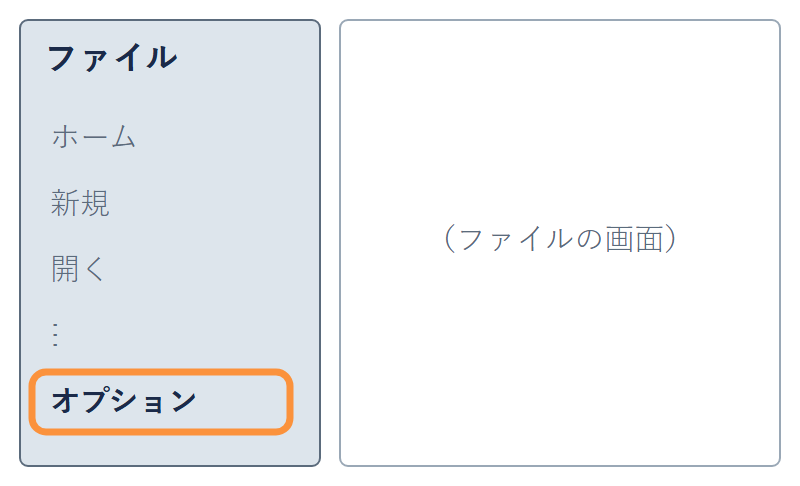

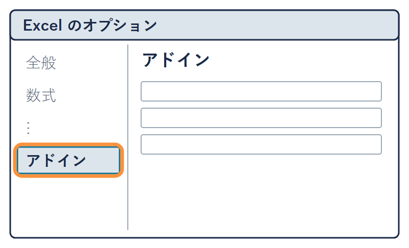

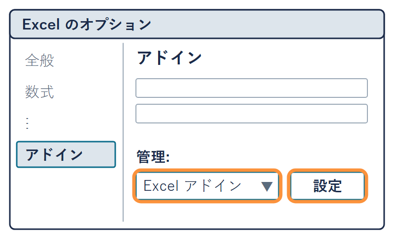

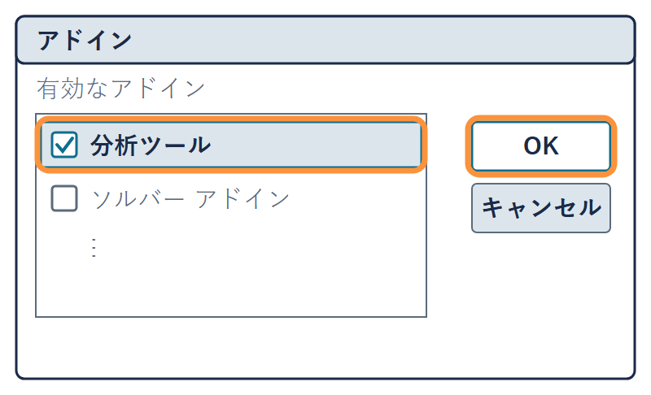

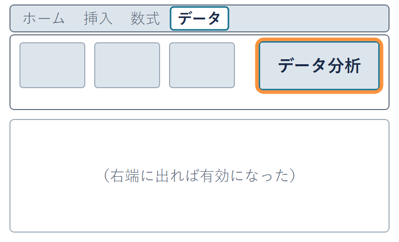

アドイン＝あとから足す追加機能。既定では無効なので、  
**全員がここで済ませておく**

## Windows と Mac の入口の違い

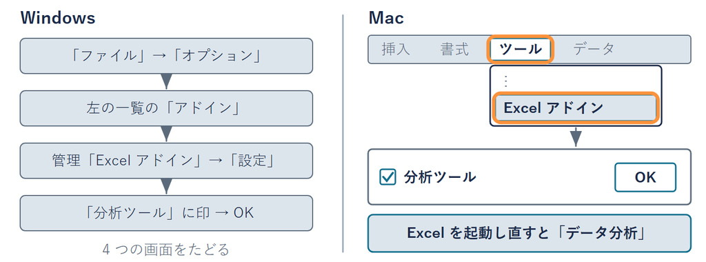

Mac は「ツール」→「Excel アドイン」の 2 手。印を付けたら Excel を起動し直す

## Excel と生成 AI の役割分担

| 観点 | Excel | チャットで聞く AI |
| --- | --- | --- |
| データ | シートに残り、 いつでも見直せる | 貼った分だけ。 やり取りの途中は残りにくい |
| 計算の途中 | 式がセルに残る （`=SUM(C2:C13)`） | 答えは返るが、 元データと式は手元に残らない |
| 1 マス直す | 式が追いかけて、答えも変わる | 聞き直すまで前の答えのまま |
| 速さと誤り | 自分で操作する手間がかかる | 速いが、間違えることがある |

だからこの授業では、元データと式を **Excel** に残し  
AI の答えと**照らし合わせる**

## AI 検証ループ — まず自分で、それから AI

決まり

**①予想 → ②自分で操作 → ③AI にも → ④突き合わせ**  
**→ ⑤ずれたら原因探し**。②と③を逆にしない

- **なぜ自分が先か**：先に AI に聞くと、  
  その答えが頭に残って手が動かなくなる
- **③で頼むこと**：(a) 数値は計算を、(b) 出典はどの統計のどの表かを
- **ずれたら**：失敗ではなく発見。自分のミスか AI のミスかを探す

AI は答えを出す相手ではなく、**自分の答えを突き合わせる相手**

## 5 段と、突き合わせる相手

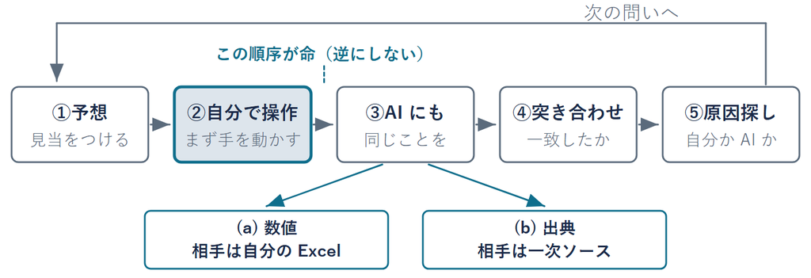

答え合わせの相手は、(a) 数値なら自分の Excel、(b) 出典なら一次ソース

## 小さく聞く — 渡すのは数値だけ

表を丸ごと渡す  
ファイルごと貼って  
「平均を教えて」  
何の平均かが伝わらず、  
答えがぶれる

確かめたい数だけ渡す  
「次の 5 つの数は、学生 1 人の  
5 科目の点数です（満点は 100）：  
72, 85, 63, 90, 55  
平均点を計算してください」

- **4 つの要素**：何の数か／単位と前提／数そのもの／頼みは 1 つ
- **出典を聞くとき**：作成機関・統計名・調査年・表名を名指しする
- **なぜ小さく**：個人に結びつく情報は渡さない。  
  答えも小さく、突き合わせやすい

## (a) 数値 — 今年の 12 個で回す

1. **予想する**：毎月 14,000 前後が 12 か月なら、合計は 16 万台か
2. **自分で出す**：SUM と AVERAGE で 168,025 と 14,002.08
3. **AI に聞く**：今年の 12 個だけを貼り、合計と平均を頼む（単位は億円）
4. **突き合わせる**：数と、説明の中身（平均 ＝ 合計 ÷ 個数）の両方

使う AI は、自分がよく使っている生成 AI（Gemini・ChatGPT など）でよい

一致したときの反応は「AI すごい」ではなく「よし、確かめられた」

## AI の答えを、自分のシートで確かめる

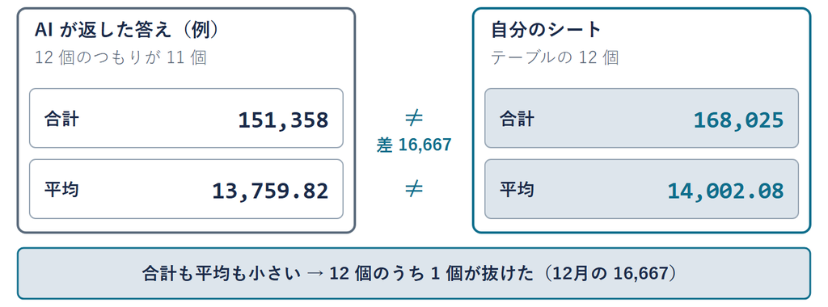

自分のシートで再現できて初めて、「確かめた」と言える

## (b) 出典 — 出典を言えない数字は、使わない

決まり

AI の答えは**二次ソースの極致**  
だから**出典を言えない数字は、使わない**

| 確かめる項目 | AI がよく外すところ |
| --- | --- |
| 統計名・作成機関 | 商業動態統計調査ではなく、別の統計を挙げる |
| 表の名前 | 「業態別」か「業種別」かを区別しない |
| 単位 | 億円か百万円かを言わない（桁が 100 倍ずれる） |
| 速報か確報か | 触れない。取得日が無いと再現できない |
| URL | 開けない。または別の内容のページに飛ぶ |

示された URL を開くまでが検証。**取得日だけは AI に書けない**

## Q&A

Q1 グラフの線が、最後の点だけ天井まで跳ねた

合計の行まで範囲に入っている。集計行を外して描き直す

Q2 Mac で「データ分析」が出てこない

「ツール」→「Excel アドイン」で印を付け、Excel を起動し直す

Q3 AI に先に聞いたら、自分で計算する気が消えた

順序を戻す。**自分のシートで出してから**、同じことを頼む

Q4 AI が挙げた表名を、そのまま出典に書いた

開いて確かめるまでは出典ではない。開けない行こそが成果

## 演習 1-4 — 線と言葉と突き合わせ

演習 1-4

折れ線を描いて 1 行で語り、AI の答えを突き合わせる

- 同じシートの表から、折れ線を描いて整える  
  （Windows は 2 つの道で。Mac は道 2 の「挿入」から）
- 動きを数字つきで 1 行、下に出典を 1 行。分析ツールも有効にする
- AI 検証の (a) 数値と (b) 出典を回し、結果をシートに記入する

✋ 動画を止めて 10 分。記入したら再生に戻る

今日の型は 3 つ — 出どころ・自分の手・突き合わせ。この 3 つを毎回まわす